# Лабораторная работа 9

1132232887

Накова А. М.

Российский университет дружбы народов, Москва, Россия

17 февраля 2025

# Цель работы

# Цель работы

Целью данной работы является получение навыков работы с контекстом безопасности и политиками SELinux.

# Выполнение лабораторной работы

Запустим терминал и получим полномочия администратора: su -. Затем просмотрим текущую информацию о состоянии SELinux: sestatus -v :

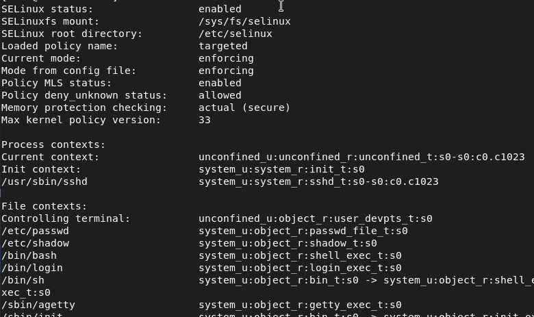

шаг 1

#Посмотрим, в каком режиме работает SELinux: getenforce. По умолчанию SELinux находится в режиме принудительного исполнения (Enforcing). Изменим режим работы SELinux на разрешающий (Permissive): setenforce 0 и снова введём getenforce. Откроем файл /etc/sysconfig/selinux с помощью текстового редактора mcedit:

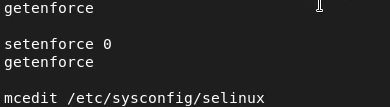

шаг 2

#В открытом в редакторе файле /etc/sysconfig/selinux установим SELINUX=disabled. После чего сохраним изменения :

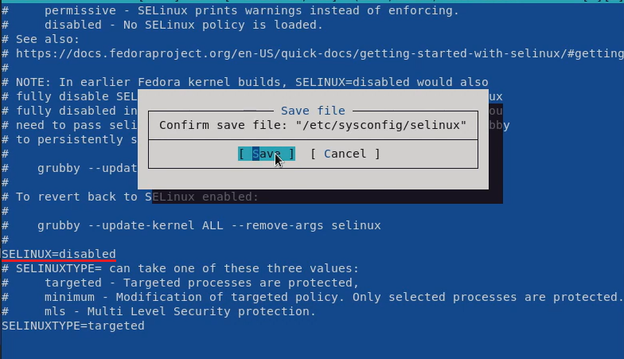

шаг 3

#Выполним перезагрузку системы:

#После перезагрузки запустим терминал и получим полномочия администратора. Далее посмотрим статус SELinux: getenforce. Мы видим, что SELinux теперь отключён. Попробуем переключить режим работы SELinux: setenforce 1. Система пишет, что SELinux отключён, так как мы не можете переключаться между отключённым и принудительным режимом без перезагрузки системы. Откроем файл /etc/sysconfig/selinux с помощью текстового редактора mcedit

#В открытом в редакторе файле /etc/sysconfig/selinux установим SELINUX=enforcing. После чего сохраним изменения:

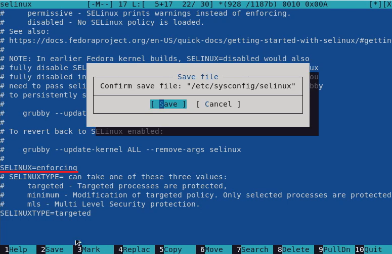

шаг 6

#Выполним перезагрузку системы:

#Во время загрузки системы мы получили предупреждающее сообщение о необходимости восстановления меток SELinux:

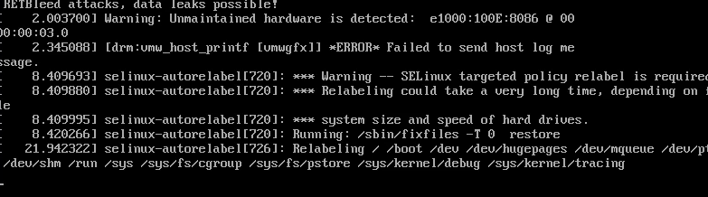

шаг 8

#После перезагрузки в терминале с полномочиями администратора просмотрим текущую информацию о состоянии SELinux: sestatus -v. Убедимся, что система работает в принудительном режиме (enforcing) использования SELinux:

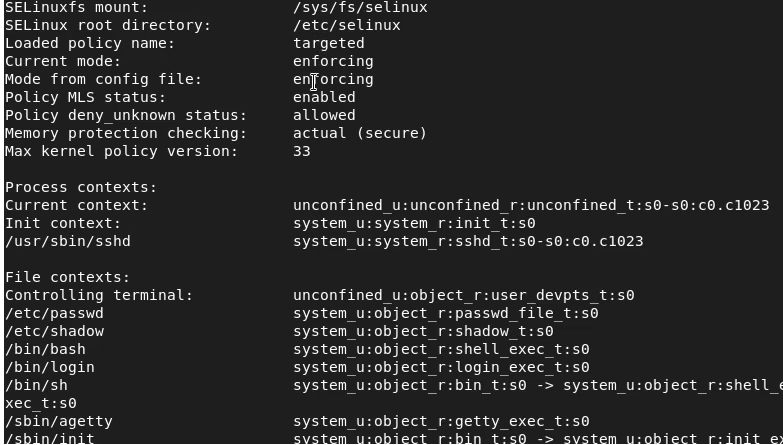

шаг 9

#Использование restorecon для восстановления контекста безопасности: Запустим терминал и получим полномочия администратора. Просмотрим контекст безопасности файла /etc/hosts: ls -Z /etc/hosts. Мы видим, что у файла есть метка контекста net_conf_t. Скопируем файл /etc/hosts в домашний каталог: cp /etc/hosts ~/. Затем проверим контекст файла ~/hosts: ls -Z ~/hosts. Поскольку копирование считается созданием нового файла, то параметр контекста в файле ~/hosts, расположенном в домашнем каталоге, стал admin_home_t. Попытаемся перезаписать существующий файл hosts из домашнего каталога в каталог /etc: mv ~/hosts /etc и подтвердим, что мы хотим сделать это. После чего нам нужно убедиться, что тип контекста по-прежнему установлен на admin_home_t: ls -Z /etc/hosts. Исправим контекст безопасности: restorecon -v /etc/hosts. Опция -v покажет процесс изменения. Убедимся, что тип контекста изменился: ls -Z /etc/hosts. Для массового исправления контекста безопасности на файловой системе введём touch /.autorelabel и перезагрузим систему.

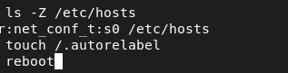

шаг 10

#Во время перезапуска не забываем нажать клавишу Esc на клавиатуре, чтобы мы видели загрузочные сообщения. Мы видим, что файловая система автоматически перемаркирована

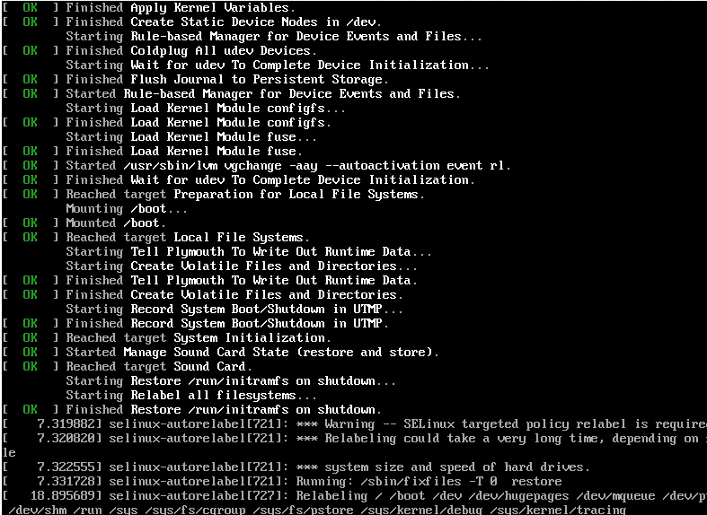

# Выводы

получили навыков работы с контекстом безопасности и политиками SELinux.